# proteomicAge: User Manual & Complete Pipeline

ClawBio

2026-06-18

# Overview

`proteomicAge` computes biological age from plasma proteomic data using published proteomic aging clocks. This vignette covers every function in the package and demonstrates a complete analysis pipeline from raw SOMAscan data to a finished report.

# Installation

```r
remotes::install_github("ClawBio/ClawBio", subdir = "proteomicAge")

# Recommended: install SomaScan.db for full protein name mapping
BiocManager::install("SomaScan.db")
```

# Function Reference

## Clock Functions

### `tanaka2018_proteins()` / `lehallier2019_proteins()`

List the proteins (and their coefficients) used in each clock.

```r
prots <- tanaka2018_proteins()
head(prots[, c("SOMAID", "Gene", "Weight")], 10)
```

```
##      SOMAID     Gene     Weight
## 2  SL012561     REG4  3.0044233
## 3  SL003340   CHI3L1  0.3610525
## 4  SL005430   SECTM1  2.9942787
## 5  SL007631     SOST  5.6044688
## 6  SL018256     CHKB -2.7911018
## 7  SL011888    SMOC1  2.8864798
## 8  SL018587    ISLR2 -0.8708658
## 9  SL017424 C10orf54 -0.1881126
## 10 SL017106   IFNA10  0.0235057
## 11 SL004139    EFNA3 -3.0017857
```

```r
lh <- lehallier2019_proteins()
cat("Lehallier 2019 proteins:", nrow(lh), "\n")
```

```
## Lehallier 2019 proteins: 373
```

```r
head(lh[, c("SOMAID", "Gene", "Weight")], 10)
```

```
##                SOMAID     Gene    Weight
## 2    SCARF2.8956.96.3   SCARF2  2.259681
## 3    ARFIP2.12630.8.3   ARFIP2  1.734075
## 4     SOST.13101.60.3     SOST  1.685101
## 5       PTN.3045.72.2      PTN  1.640670
## 6    WFDC2.11388.75.3    WFDC2  1.354360
## 7      AGRP.2813.11.2     AGRP -1.284708
## 8     GDF15.4374.45.2    GDF15  1.275807
## 9    MXRA8.10521.10.3    MXRA8  1.079100
## 10  IGDCC4.9793.145.3   IGDCC4 -1.076530
## 11 CGA.FSHB.3032.11.2 CGA_FSHB  1.006121
```

### `compute_tanaka2018_age()`

Compute proteomic biological age using the Tanaka et al. (2018) 76-protein clock.

```r
# Create demo data with gene symbols
demo <- data.frame(
  SampleID = paste0("S", 1:5),
  Age      = c(30, 45, 55, 65, 80)
)

# Add a few known proteins
demo[["GDF15"]]   <- c(1500, 3000, 5000, 8000, 15000)
demo[["CHI3L1"]]  <- c(1200, 1800, 2500, 4000, 6000)
demo[["SOST"]]    <- c(800,  1200, 2000, 3500, 5000)
demo[["PTN"]]     <- c(900,  1500, 2200, 3800, 5500)
demo[["ADAMTS5"]] <- c(1000, 2000, 3000, 4500, 7000)

# Compute — uses SomaScan.db to auto-map gene → SeqId
result <- compute_tanaka2018_age(demo, protein_format = "gene")
print(result)
```

```
##   id chronological_age proteomic_age age_acceleration n_proteins_matched
## 1 S1                30      264.0285       -0.0425992                  5
## 2 S2                45      278.1545       -1.1669203                  5
## 3 S3                55      289.6933        0.2051292                  5
## 4 S4                65      302.1780        2.5229294                  5
## 5 S5                80      313.3868       -1.5185391                  5
##   n_proteins_missing
## 1                 71
## 2                 71
## 3                 71
## 4                 71
## 5                 71
```

**Parameters:**

| Parameter | Default | Description |
| --- | --- | --- |
| `data` | (required) | Data frame with sample ID, age, and protein columns |
| `id_col` | `"SampleID"` | Name of sample identifier column |
| `age_col` | `"Age"` | Name of chronological age column |
| `log_transform` | `TRUE` | Apply log₂ transform (match paper’s preprocessing) |
| `protein_format` | `"auto"` | Format of protein columns: `"gene"`, `"uniprot"`, `"seqid_dot"`, `"seqid_sl"`, `"auto"` |

### `compute_lehallier2019_age()`

Compute proteomic age using the Lehallier et al. (2019) 373-protein LASSO clock.

```r
# Input can use gene symbols, uniProt, or SeqIds
demo_lh <- data.frame(
  SampleID = paste0("S", 1:3),
  Age = c(35, 55, 75)
)
demo_lh[["GDF15"]]  <- c(2000, 5000, 12000)
demo_lh[["SCARF2"]] <- c(800, 1500, 3000)
demo_lh[["SOST"]]   <- c(1000, 2500, 4500)

result_lh <- compute_lehallier2019_age(demo_lh, protein_format = "gene")
print(result_lh)
```

```
##   id chronological_age proteomic_age age_acceleration n_proteins_matched
## 1 S1                35      66.65797      -0.03328193                  3
## 2 S2                55      68.45313       0.06656387                  3
## 3 S3                75      70.04860      -0.03328193                  3
##   n_proteins_missing
## 1                370
## 2                370
## 3                370
```

**Additional parameters (vs Tanaka clock):**

| Parameter | Default | Description |
| --- | --- | --- |
| `sex_col` | `"Sex"` | Sex column name (0 = male, 1 = female) |
| `male_value` | `0` | Value coding for male |

**Key differences from Tanaka clock:**

|  | Tanaka 2018 | Lehallier 2019 |
| --- | --- | --- |
| Log transform | log₂ | log₁₀ |
| Scaling | None | Z-scaling (approximate) |
| Covariates | None | Sex |
| Intercept | 90.22 | 50.83 |

## Protein Name Mapping

### `normalize_protein_names()`

Normalize protein column names from any format to a target format. This is called automatically by the clock functions, but you can use it standalone.

```r
data <- data.frame(
  SampleID = "S1",
  Age = 50,
  GDF15 = 5000,
  CHI3L1 = 3000,
  `4374.45.2` = 2000
)

# Convert gene symbols → Tanaka SL format
data_sl <- normalize_protein_names(data, target_format = "seqid_sl", input_format = "gene")
names(data_sl)
```

```
## [1] "SampleID"   "Age"        "SL003869"   "SL003340"   "X4374.45.2"
```

```r
# Convert gene symbols → Lehallier format
data_full <- normalize_protein_names(data, target_format = "seqid_full", input_format = "gene")
names(data_full)
```

```
## [1] "SampleID"          "Age"               "GDF15.4374.45.2"
## [4] "CHI3L1.11104.13.3" "X4374.45.2"
```

### `detect_column_format()`

Auto-detect the format of protein column names.

```r
detect_column_format(c("GDF15", "CHI3L1", "SOST"))        # gene
```

```
## [1] "gene"
```

```r
detect_column_format(c("4374.45.2", "11104.13.3"))         # seqid_dot
```

```
## [1] "seqid_dot"
```

```r
detect_column_format(c("SL003869", "SL003340"))            # seqid_sl
```

```
## [1] "seqid_sl"
```

```r
detect_column_format(c("GDF15.4374.45.2", "SCARF2.8956.96.3"))  # seqid_full
```

```
## [1] "seqid_full"
```

## Preprocessing

### `preprocess_somascan()`

Preprocess raw SOMAscan RFU data before clock computation.

```r
raw <- data.frame(
  SampleID = 1:100,
  SL003869 = c(rnorm(98, mean = 8, sd = 1), 20, -5),  # two outliers
  SL003340 = rnorm(100, mean = 7, sd = 1.5)
)

processed <- preprocess_somascan(raw,
  log_transform = TRUE,
  handle_outliers = TRUE,
  report_missingness = TRUE
)
```

```
##
## --- Missing Value Summary ---
## Total samples: 100
## Proteins with any missing values: 1 / 2
##
## Top proteins by missingness:
##           Protein N_missing Pct_missing
## SL003869 SL003869         1           1
## -----------------------------
```

**Parameters:**

| Parameter | Default | Description |
| --- | --- | --- |
| `data` | (required) | Data frame with protein columns |
| `protein_cols` | `NULL` | Which columns are proteins (auto-detect by default) |
| `log_transform` | `TRUE` | Apply log₂ transformation |
| `handle_outliers` | `TRUE` | Winsorize at ±4 SD |
| `report_missingness` | `TRUE` | Print missing value summary |

### `validate_somascan_input()`

Check data quality before running a clock.

```r
validate_somascan_input(demo)  # from earlier example
```

```
## === SOMAscan Input Validation ===
## Samples: 5
## Total columns: 7
##
## WARNINGS:
##   - Protein coverage: 0.0% (0/76). Missing: SL012561, SL003340, SL005430, SL007631, SL018256, SL011888, SL018587, SL017424, SL017106, SL004139, SL004010, SL003193, SL000045, SL000546, SL002644, SL005217, SL021043, SL006924, SL002081, SL004644, SL003173, SL000428, SL004354, SL002704, SL004626, SL0…
##
## Protein coverage: 0.0% (0/76 required proteins found)
## Overall: VALID
## ==================================
```

# Complete Pipeline

This section walks through a complete analysis: raw SOMAscan data → clean data → proteomic age → report.

## Step 1: Load Raw Data

```r
# Simulate a realistic SOMAscan dataset (samples × proteins in RFU)
set.seed(123)
n_samples <- 50
prots <- tanaka2018_proteins()

raw_data <- data.frame(
  SampleID = paste0("P", sprintf("%03d", 1:n_samples)),
  Age = round(runif(n_samples, 25, 85), 1),
  Sex = sample(c(0, 1), n_samples, replace = TRUE)
)

for (i in 1:nrow(prots)) {
  raw_data[[prots$SOMAID[i]]] <-
    rlnorm(n_samples, meanlog = log(2000), sdlog = 0.5)
}

cat("Loaded:", nrow(raw_data), "samples ×", ncol(raw_data), "columns\n")
```

```
## Loaded: 50 samples × 79 columns
```

## Step 2: Validate Input

```r
validate_somascan_input(raw_data)
```

```
## === SOMAscan Input Validation ===
## Samples: 50
## Total columns: 79
##
## Protein coverage: 100.0% (76/76 required proteins found)
## Overall: VALID
## ==================================
```

## Step 3: Preprocess

```r
clean_data <- preprocess_somascan(raw_data, report_missingness = FALSE)
cat("Preprocessed. Any outliers winsorized, log₂ applied.\n")
```

```
## Preprocessed. Any outliers winsorized, log₂ applied.
```

## Step 4: Compute Proteomic Age

Apply both clocks to compare results.

```r
# Tanaka 2018 clock (note: data already log-transformed)
tanaka_age <- compute_tanaka2018_age(clean_data, log_transform = FALSE)
tanaka_age$Age <- clean_data$Age

# Lehallier 2019 clock (on gene-symbol version of the same data)
gene_data <- raw_data
names(gene_data) <- c("SampleID", "Age", "Sex", prots$Gene)
leh_age <- compute_lehallier2019_age(gene_data, protein_format = "gene")
leh_age$Age <- gene_data$Age

cat("Done. Computed proteomic age for", nrow(tanaka_age), "samples.\n")
```

```
## Done. Computed proteomic age for 50 samples.
```

## Step 5: Analyze Results

```r
# Correlation with chronological age
cor_tanaka <- cor(tanaka_age$Age, tanaka_age$proteomic_age, use = "complete.obs")
cor_leh    <- cor(leh_age$Age, leh_age$proteomic_age, use = "complete.obs")

cat("Tanaka  correlation (predicted vs chronological):", round(cor_tanaka, 3), "\n")
```

```
## Tanaka  correlation (predicted vs chronological): 0.037
```

```r
cat("Lehallier correlation (predicted vs chronological):", round(cor_leh, 3), "\n")
```

```
## Lehallier correlation (predicted vs chronological): -0.038
```

```r
# Age acceleration summary
cat("\nTanaka age acceleration:\n")
```

```
##
## Tanaka age acceleration:
```

```r
cat("  Mean:", round(mean(tanaka_age$age_acceleration, na.rm = TRUE), 4), "(≈ 0)\n")
```

```
##   Mean: 0 (≈ 0)
```

```r
cat("  SD:  ", round(sd(tanaka_age$age_acceleration, na.rm = TRUE), 2), "\n")
```

```
##   SD:   12.78
```

```r
cat("  Range:", round(range(tanaka_age$age_acceleration, na.rm = TRUE), 2), "\n")
```

```
##   Range: -34.28 27.09
```

```r
# Top age-accelerated individuals
tanaka_age <- tanaka_age[order(-tanaka_age$age_acceleration), ]
cat("\nTop 3 age-accelerated:\n")
```

```
##
## Top 3 age-accelerated:
```

```r
print(head(tanaka_age[, c("id", "Age", "proteomic_age", "age_acceleration")], 3))
```

```
##      id  Age proteomic_age age_acceleration
## 1  P001 42.3     101.89405         27.08593
## 2  P002 72.3      99.76024         24.14419
## 50 P050 76.5      95.42889         19.69972
```

```r
cat("\nTop 3 age-decelerated:\n")
```

```
##
## Top 3 age-decelerated:
```

```r
print(tail(tanaka_age[, c("id", "Age", "proteomic_age", "age_acceleration")], 3))
```

```
##      id  Age proteomic_age age_acceleration
## 20 P020 82.3      51.57235        -24.31302
## 22 P022 66.6      48.64114        -26.82141
## 42 P042 49.9      40.73545        -34.27734
```

## Step 6: Visualize

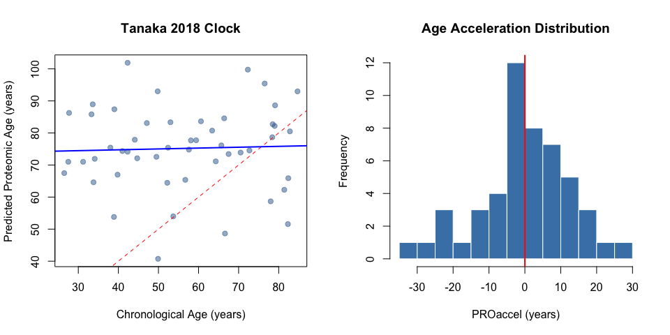

```r
par(mfrow = c(1, 2))

# Tanaka: predicted vs chronological
plot(tanaka_age$Age, tanaka_age$proteomic_age,
     main = "Tanaka 2018 Clock",
     xlab = "Chronological Age (years)",
     ylab = "Predicted Proteomic Age (years)",
     pch = 19, col = rgb(0.2, 0.4, 0.6, 0.5))
abline(0, 1, lty = 2, col = "red")
abline(lm(proteomic_age ~ Age, data = tanaka_age), col = "blue", lwd = 2)

# Distribution of age acceleration
hist(tanaka_age$age_acceleration, breaks = 20,
     main = "Age Acceleration Distribution",
     xlab = "PROaccel (years)",
     col = "steelblue", border = "white")
abline(v = 0, col = "red", lwd = 2)
```

## Step 7: Compare Clocks

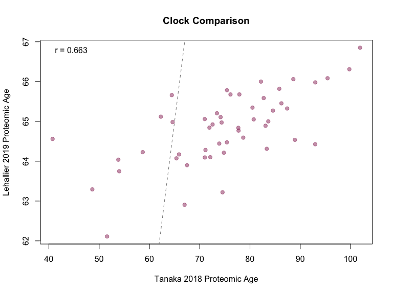

```r
# Merge by age
merged <- merge(tanaka_age[, c("id", "Age", "proteomic_age")],
                leh_age[, c("id", "Age", "proteomic_age")],
                by = "id", suffixes = c("_tanaka", "_leh"))

plot(merged$proteomic_age_tanaka, merged$proteomic_age_leh,
     main = "Clock Comparison",
     xlab = "Tanaka 2018 Proteomic Age",
     ylab = "Lehallier 2019 Proteomic Age",
     pch = 19, col = rgb(0.6, 0.2, 0.4, 0.5))
abline(0, 1, lty = 2, col = "gray50")
cor_clocks <- cor(merged$proteomic_age_tanaka, merged$proteomic_age_leh,
                  use = "complete.obs")
legend("topleft", legend = paste("r =", round(cor_clocks, 3)), bty = "n")
```

# Protein Name Mapping: Deep Dive

## When to use which format

| Your data format | Use `protein_format =` | Notes |
| --- | --- | --- |
| Gene symbols (`GDF15`) | `"gene"` | SomaScan.db maps to SeqId via ALIAS |
| UniProt IDs (`Q99988`) | `"uniprot"` | SomaScan.db required |
| Dot SeqIds (`4374.45.2`) | `"seqid_dot"` | Converts to PROBEID then maps |
| SL SeqIds (`SL003869`) | `"seqid_sl"` | Only via built-in CSV (v3 platform) |
| Full SeqIds (`GDF15.4374.45.2`) | `"seqid_full"` | Direct match |
| Not sure | `"auto"` | Auto-detection |

## Cross-clock compatibility

The same input data (with gene symbols) can be used with both clocks:

```r
data <- data.frame(
  SampleID = "S1",
  Age = 50,
  GDF15  = 5000,
  CHI3L1 = 3000,
  SOST   = 2000,
  PTN    = 4000
)

tanaka_result <- compute_tanaka2018_age(data, protein_format = "gene")
leh_result    <- compute_lehallier2019_age(data, protein_format = "gene")

# Both clocks accept the exact same input format
cat("Tanaka: ", tanaka_result$proteomic_age, "\n")
```

```
## Tanaka:  244.5586
```

```r
cat("Lehallier:", leh_result$proteomic_age, "\n")
```

```
## Lehallier: 67.41087
```

# Understanding the Output

## Age Acceleration

Age acceleration = residuals of `lm(PROage ~ chronological_age)`.

- **≈ 0**: Biological age matches chronological age for the population average
- **> 0**: Predicted older than expected (accelerated aging)
- **< 0**: Predicted younger than expected (decelerated aging)

This is NOT simply `PROage - Age`. Using residuals accounts for the systematic relationship between predicted and chronological age.

## When proteins are missing

The `n_proteins_matched` and `n_proteins_missing` columns show coverage. Results with many missing proteins should be interpreted cautiously:

```r
if (any(tanaka_age$n_proteins_missing > 0)) {
  cat("Some samples are missing proteins.\n")
  cat("Consider the SomaScan panel version compatibility.\n")
}
```